# ESPM 174A - Homework assignment 2

Emily Barnes

9/22/2020

```r
library(dplyr)
library(tidyverse)

library(scales)

library(akima)
library(lubridate)
#library(asbio)
#library(tmap)         # raster + vector layers
#library(raster)       # Main raster library
#library(tidyverse)    # our old friend
#library(sf)           # to work with simple features data
#library(mapview)
library(openxlsx)
library(class)
library(RANN)
library("survival")
library("Hmisc")


#install.packages("survival")

library(lattice)
#install.packages("latticeExtra")


library(survival)
library(Hmisc)
library(plot.matrix)

#install.packages("EnvStats")
library(EnvStats)
#install.packages("installr")
#library(installr)
```

### Instructions

Work on the exercise below, due September 23 (before midnight) on bCourses. Please write **short answers (<100 words)** in “your text here”, as well as the R code you used to get there (in “your code here”).

### Exercise

1. Please upload a sample of the data (.csv file) you plan to analyze for your final project. You can (but do not need to) upload the whole dataset. However, the closer the resemblance of this data set to the one you will end up analyzing, the better. E.g., if your question is at the community level, then include several species; if you would like to compare a particular physical variable across different sites, then include several sites. The goal is for you to start getting familiar with your data and its level of complexity. In the code below, import your data set in R, and examine the following properties: (1) length and frequency of the time series (whether it is one, or multiple time series); (2) completeness of each time series; (3) basic descriptive statistics for each time series (at least mean, CV, ACF for each variable; plus anything else you would like to add). [3 points total]

[output not shown]

[output cut: 38 more lines]

[output not shown]

[output cut: 113 more lines]

```r
# filtering out bad LRI matches
Match_factor_floor <- 750
Reverse_match_factor_floor <- 100
LRI_diff_floor <- 6




fb_match_factor_floor <- 600
fb_reverse_match_factor_floor <- 100
IS_lib_name <- "amzi0503_b"
FB_lib_name <- "amz_fb_trimmed_esrem"

rt2_floor <- .5 # note: check on this, but for purposes of indexing retention times in 2d this is important

# creating a column of the differences in linear retention indecies so that poor matches can be screened out
M_t_LRI <- M_t_full %>% mutate(LRI_diff = abs(Library.RI-LRI.I)) %>%
  mutate(LRI_diff = replace_na(LRI_diff, -999))

# identifying the internal standard
IS_goodmatch <- M_t_LRI %>%
  filter(Library.Name == IS_lib_name | Library.Name == "-") %>%
  filter(LRI_diff < LRI_diff_floor| Compound.Name == "4-methoxy-benzaldehyde") %>%
  filter(Library.Match.Factor > Match_factor_floor | Compound.Name == "methoxyphenol-d3")

FB_goodmatch <- M_t_LRI %>%
  filter(Library.Name == FB_lib_name) %>%
  filter(LRI_diff < LRI_diff_floor) %>%
  filter(Library.Match.Factor > fb_match_factor_floor)

FB_okmatch <- M_t_LRI %>%
  filter(Library.Name == FB_lib_name) %>%
  filter(Library.Match.Factor> fb_match_factor_floor-100) %>%
  anti_join(FB_goodmatch)
IS_okmatch <- M_t_LRI %>%
  filter(Library.Name == IS_lib_name | Library.Name == "-") %>%
  filter(Library.Match.Factor > Match_factor_floor-100 | Compound.Name == "methoxyphenol-d3")  %>%
  anti_join(IS_goodmatch)
small_poorlymatched <- M_t_LRI %>%
  filter(Compound.Name != "methoxyphenol-d3") %>%
  filter(Library.Match.Factor < Match_factor_floor) %>%
  filter(Volume < 200)

M_t_all_analytes <- M_t_LRI %>%
  anti_join(FB_goodmatch) %>%
  anti_join(IS_goodmatch) %>%
  anti_join(FB_okmatch) %>%
  anti_join(IS_okmatch) %>%
  anti_join(small_poorlymatched) %>%
  filter(LRI.I > 1300)
M_t_analyte_unique <- M_t_all_analytes %>%
  filter(Library.Name != IS_lib_name) %>%
  filter(Library.Name != FB_lib_name) %>%
  filter(LRI_diff < LRI_diff_floor) %>%
  filter(Library.Match.Factor > Match_factor_floor | Description == "match") %>%
  #filter(Library.Reverse.Match.Factor > Reverse_match_factor_floor) %>%
  arrange(desc(Volume)) %>%
  arrange(Compound.Name) %>%
  arrange(r_date) %>%
  distinct(Compound.Name, r_date, .keep_all = TRUE)
```

```r
fulldates_iop1 <- read_csv("Blob_table_summary_fulldates_iop1.csv") %>%
  dplyr::select(AMZ_date, date_num) %>%
  mutate(r_date =   convertToDateTime(date_num)) %>%
  mutate(r_date.f = as.factor(r_date)) %>%
  filter(!is.na(r_date))
fulldates_iop2 <- read_csv("Blob_table_summary_fulldates_iop2.csv") %>%
  dplyr::select(AMZ_date, date_num) %>%
  mutate(r_date =  mdy_hm(AMZ_date)) %>%
  mutate(r_date.f = as.factor(r_date)) %>%
  filter(!is.na(r_date))
fulldates <- rbind(fulldates_iop1, fulldates_iop2)

# M_t_full_0filled <- M_t_analyte_unique_IS %>%
#   dplyr::select(Compound.Name, r_date, vol_is_normnorm_ptnorm) %>%
#   spread(Compound.Name, vol_is_normnorm_ptnorm, fill = 0) %>%
#   gather(key = "Compound.Name", value = "vol_is_normnorm_ptnorm", -r_date)

# M_t_analyte_unique_IS_0filled.r <- M_t_analyte_unique_IS %>%
#   dplyr::select(Compound.Name, r_date, vol_is_rawnorm_ptnorm) %>%
#   spread(Compound.Name, vol_is_rawnorm_ptnorm, fill = 0) %>%
#   gather(key = "Compound.Name", value = "vol_is_rawnorm_ptnorm", -r_date)

M_t_analyte_unique_0filled1.w <- M_t_analyte_unique %>%
  filter(IOP == 1) %>%
  dplyr::select(Compound.Name, r_date, Punch_time_norm_vol) %>%
  spread(Compound.Name, Punch_time_norm_vol, fill = 0)

M_t_analyte_unique_0filled1.wr <- M_t_analyte_unique %>%
  filter(IOP == 1) %>%
  dplyr::select(Compound.Name, r_date, Punch_time_norm_vol) %>%
  spread(Compound.Name, Punch_time_norm_vol, fill = 0)



M_t_analyte_unique_0filled1r <- M_t_analyte_unique %>%
  filter(IOP == 1) %>%
  dplyr::select(Compound.Name, r_date, Punch_time_norm_vol) %>%
  spread(Compound.Name, Punch_time_norm_vol, fill = 0) %>%
  gather(key = "Compound.Name", value = "Punch_time_norm_vol", -r_date)

M_t_analyte_unique_0filled2.w <- M_t_analyte_unique %>%
  filter(IOP == 2) %>%
  dplyr::select(Compound.Name, r_date, Punch_time_norm_vol) %>%
  spread(Compound.Name, Punch_time_norm_vol, fill = 0)


M_t_analyte_unique_0filled2.wr <- M_t_analyte_unique %>%
  filter(IOP == 2) %>%
  dplyr::select(Compound.Name, r_date, Punch_time_norm_vol) %>%
  spread(Compound.Name, Punch_time_norm_vol, fill = 0)


M_t_analyte_unique_0filled2r <- M_t_analyte_unique %>%
  filter(IOP == 2) %>%
  dplyr::select(Compound.Name, r_date, Punch_time_norm_vol) %>%
  spread(Compound.Name, Punch_time_norm_vol, fill = 0) %>%
  gather(key = "Compound.Name", value = "Punch_time_norm_vol", -r_date)

just_1dates <- bt_sum_iop1 %>%
  mutate(in_sample = 1) %>%
  mutate(r_date.f = as.factor(r_date)) %>%
  dplyr::select(r_date.f, in_sample)

dates_leftout1 <- fulldates_iop1 %>%
  left_join(just_1dates, by = "r_date.f") %>%
  filter(is.na(in_sample)) %>%
  left_join(M_t_analyte_unique_0filled1.w, by = "r_date") %>%
  dplyr::select(-r_date.f, -in_sample, -AMZ_date, -date_num)

dates_leftout2 <- fulldates_iop2 %>%
  dplyr::select(r_date) %>%
  anti_join(bt_sum_iop2, by = "r_date") %>%
  left_join(M_t_analyte_unique_0filled2.w)
# M_t_analyte_unique_formerge <- M_t_analyte_unique %>%
#   dplyr::select(-vol_is_normnorm_ptnorm, -Punch_time_norm_vol)

M_t_analyte_unique_na1r <- rbind(M_t_analyte_unique_0filled1.wr, dates_leftout1) %>%
  gather(key = "Compound.Name", value = "Punch_time_norm_vol", -r_date)

# M_t_analyte_unique_IS_na1 <- rbind(M_t_analyte_unique_IS_0filled1.w, dates_leftout1) %>%
#   gather(key = "Compound.Name", value = "vol_is_normnorm_ptnorm", -r_date) %>%
#   left_join(M_t_analyte_unique_IS_na1r) %>%
#   left_join(analyte_cumsum1, by = "Compound.Name") %>%
#   left_join(bt_sum_iop1_tj, by = "r_date") %>%
#   left_join(IOP1_filtertimes, by = "r_date") %>%
#   left_join(Analyte_positions, by = "Compound.Name")

M_t_analyte_unique_na2r <- rbind(M_t_analyte_unique_0filled2.w, dates_leftout2) %>%
  gather(key = "Compound.Name", value = "Punch_time_norm_vol", -r_date)

# M_t_analyte_unique_IS_na2 <- rbind(M_t_analyte_unique_IS_0filled2.w, dates_leftout2) %>%
#   gather(key = "Compound.Name", value = "vol_is_normnorm_ptnorm", -r_date) %>%
#   left_join(M_t_analyte_unique_IS_na2r) %>%
#   left_join(analyte_cumsum2, by = "Compound.Name") %>%
#   left_join(bt_sum_iop2_tj, by = "r_date") %>%
#   left_join(IOP2_filtertimes, by = "r_date") %>%
#   left_join(Analyte_positions, by = "Compound.Name")

M_t_analyte_unique_na1r.w <- rbind(M_t_analyte_unique_0filled1.w, dates_leftout1)
names(M_t_analyte_unique_na1r.w) <- make.names(names(M_t_analyte_unique_na1r.w),unique = TRUE)

M_t_analyte_unique_na2r.w <- rbind(M_t_analyte_unique_0filled2.w, dates_leftout2)

names(M_t_analyte_unique_na2r.w) <- make.names(names(M_t_analyte_unique_na2r.w),unique = TRUE)
```

```r
#Focusing on second time series for this homework

M_t_analyte_unique_na2r.w <- M_t_analyte_unique_na2r.w %>%
  mutate(row.na = is.na(X1202_1412_blob_1))

natab <- table(M_t_analyte_unique_na2r.w$row.na)
natab
```

```
##
## FALSE  TRUE
##   129    72
```

```r
pct.na <- (natab[2]/(natab[2]+natab[1]))*100
pct.na
```

```
##    TRUE
## 35.8209
```

```r
min(M_t_analyte_unique_na2r.w$r_date)
```

```
## [1] "2014-09-08 02:05:00 UTC"
```

```r
max(M_t_analyte_unique_na2r.w$r_date)
```

```
## [1] "2014-10-11 09:55:00 UTC"
```

```r
M_t_analyte_unique_na2r.w$r_date[1]-M_t_analyte_unique_na2r.w$r_date[2]
```

```
## Time difference of -3.916667 hours
```

```r
ncol(M_t_analyte_unique_na2r.w)-2
```

```
## [1] 919
```

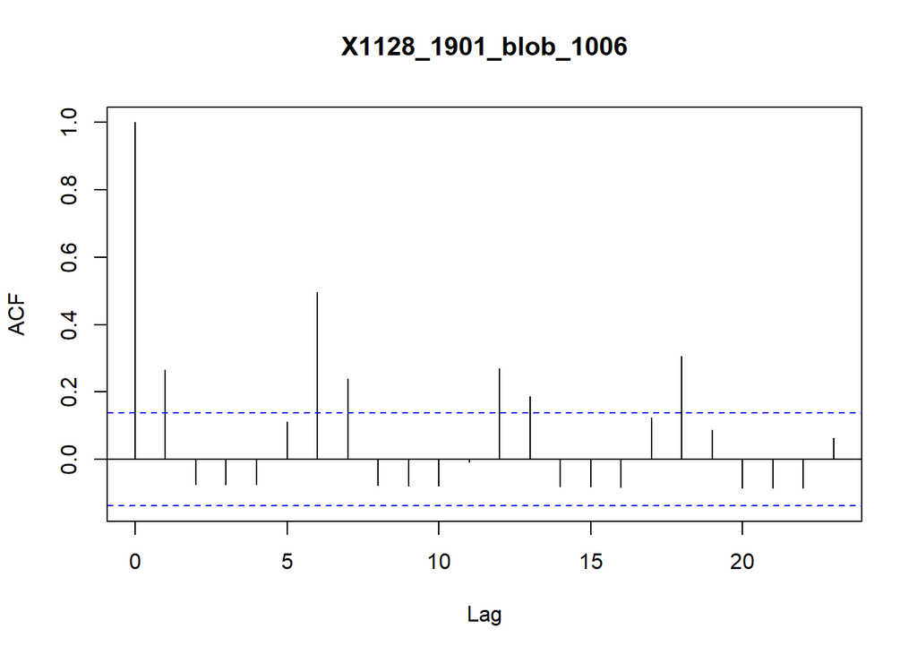

```
## [1] "X1128_1901_blob_1006 Mean: 2.64199323667042 CV: 3.71037174986876"
```

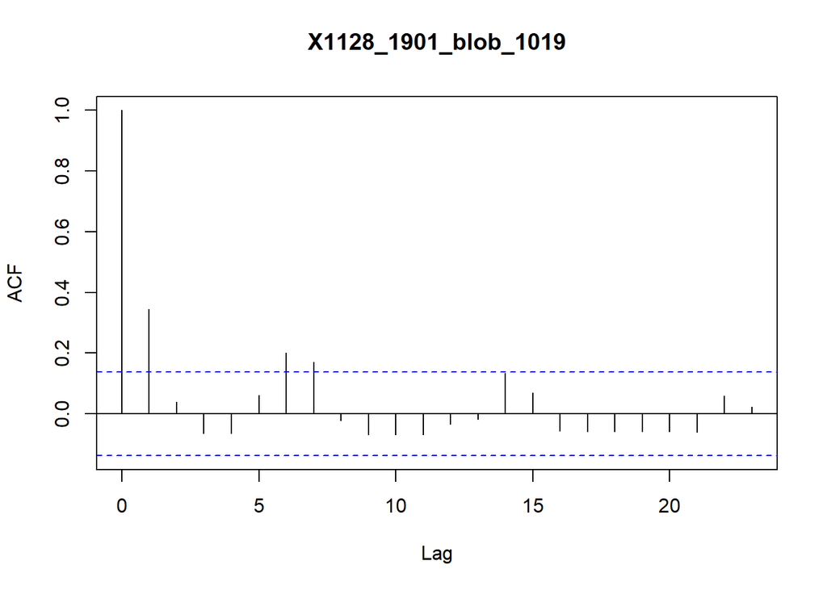

```
## [1] "X1128_1901_blob_1019 Mean: 0.940384789128069 CV: 3.98272159755557"
```

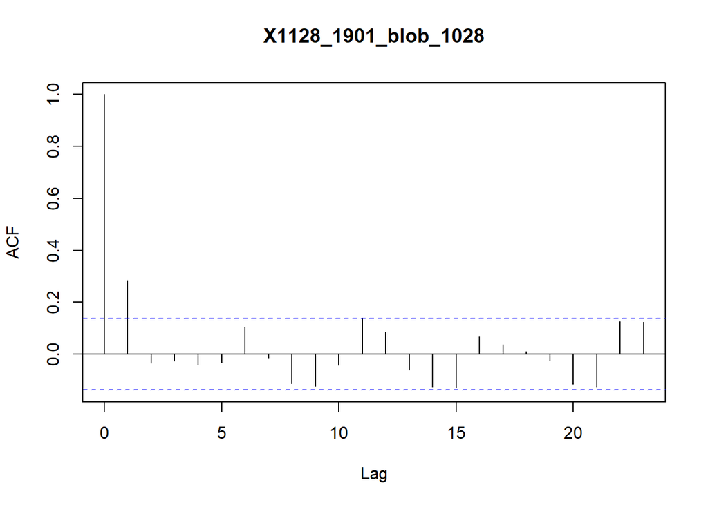

```
## [1] "X1128_1901_blob_1028 Mean: 43.0344076462647 CV: 2.17527374413397"
```

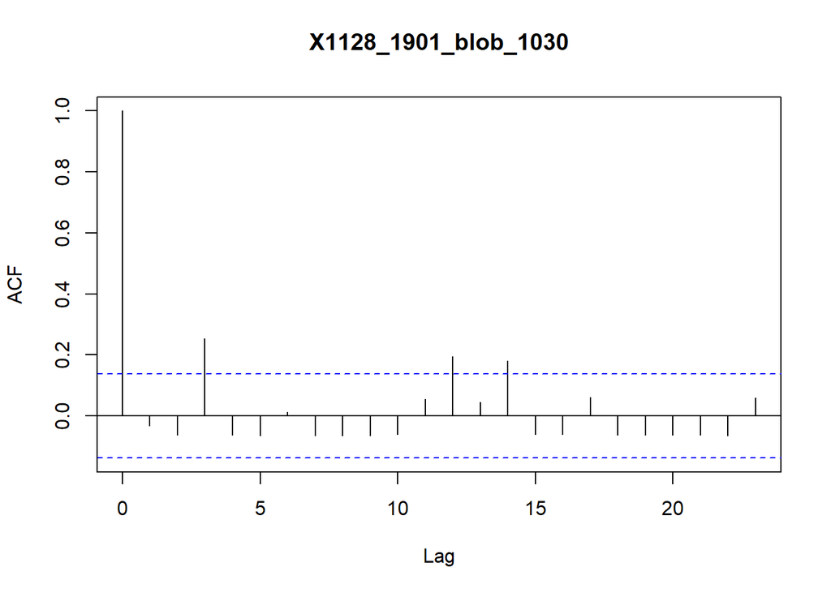

```
## [1] "X1128_1901_blob_1030 Mean: 1.39029975303059 CV: 4.04661188625745"
```

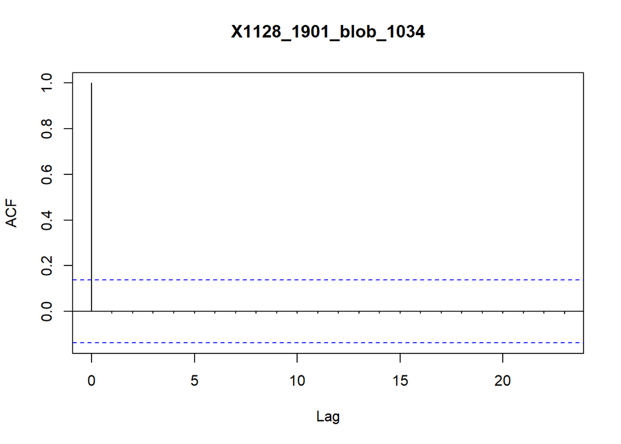

```
## [1] "X1128_1901_blob_1034 Mean: 0.0919273177920159 CV: 11.3578166916005"
```

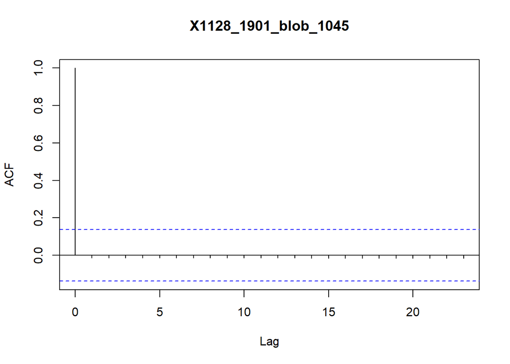

```
## [1] "X1128_1901_blob_1045 Mean: 0.19477207548649 CV: 8.53674240051483"
```

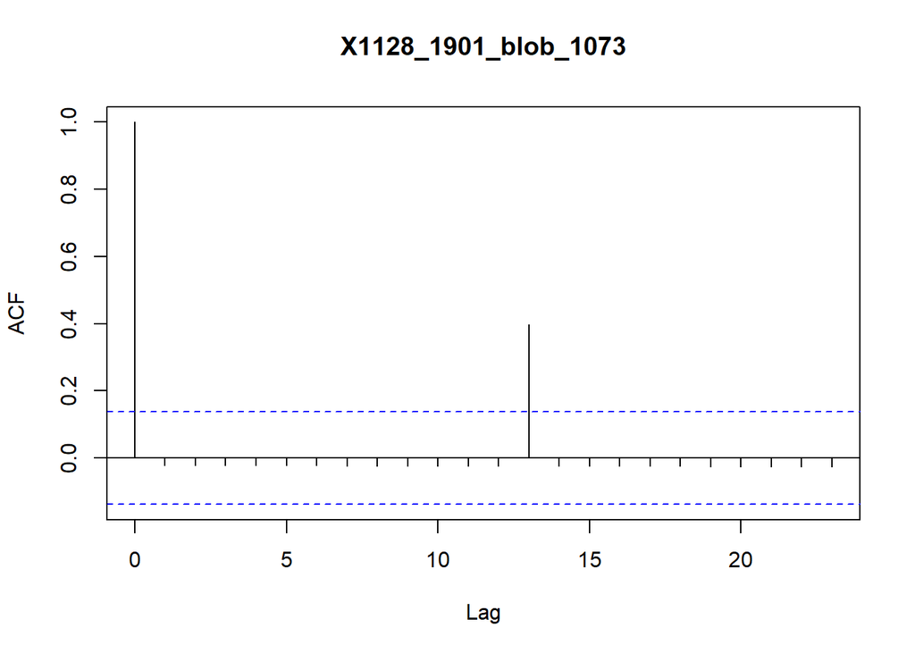

```
## [1] "X1128_1901_blob_1073 Mean: 0.246652235582215 CV: 6.73516774654262"
```

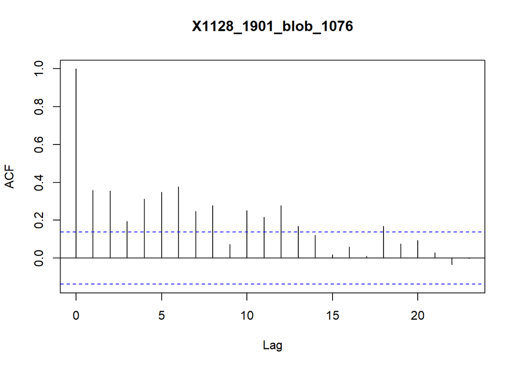

```
## [1] "X1128_1901_blob_1076 Mean: 3.54854828876947 CV: 1.69635256859316"
```

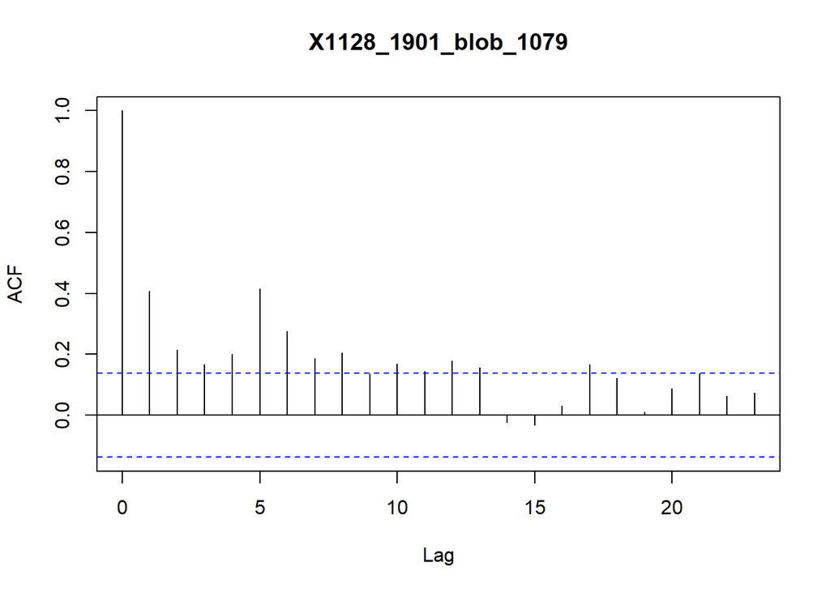

```
## [1] "X1128_1901_blob_1079 Mean: 15.5948150183725 CV: 1.73588546820463"
```

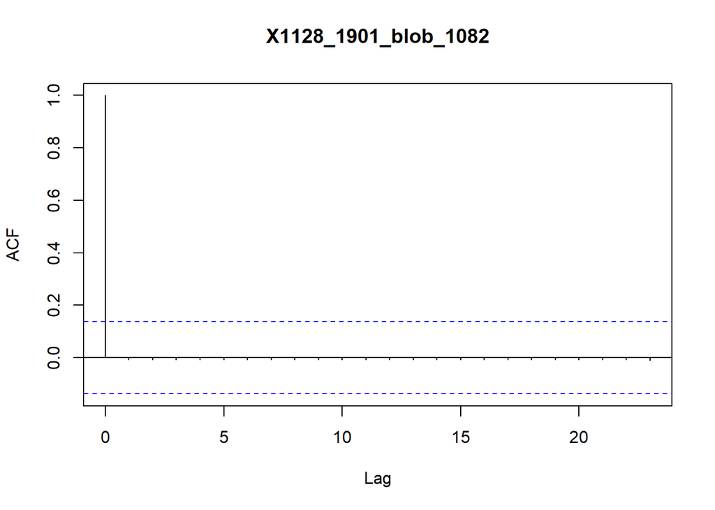

```
## [1] "X1128_1901_blob_1082 Mean: 0.234560021536876 CV: 11.3578166916005"
```

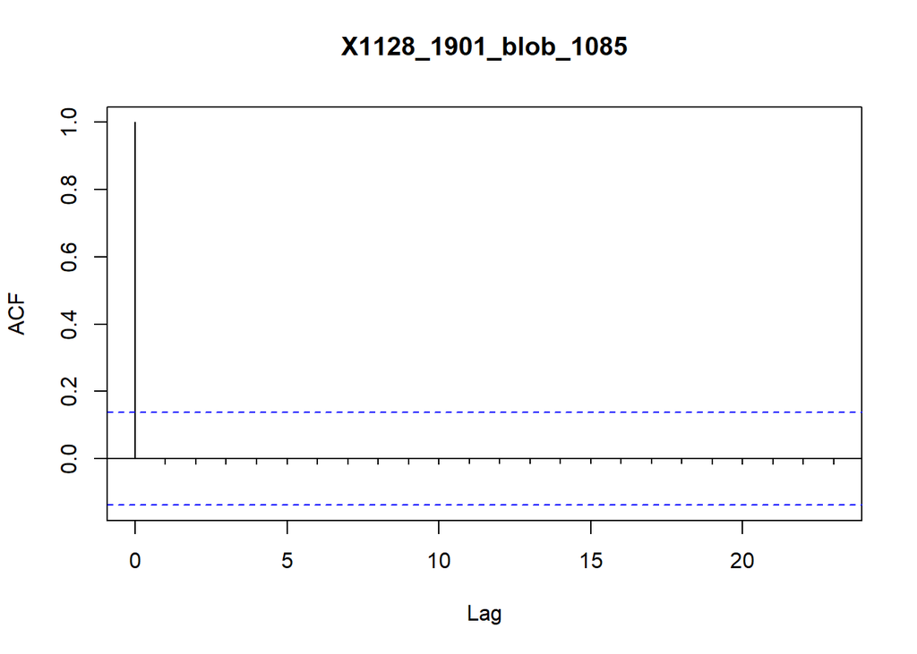

```
## [1] "X1128_1901_blob_1085 Mean: 0.577808280992329 CV: 8.09164028328001"
```

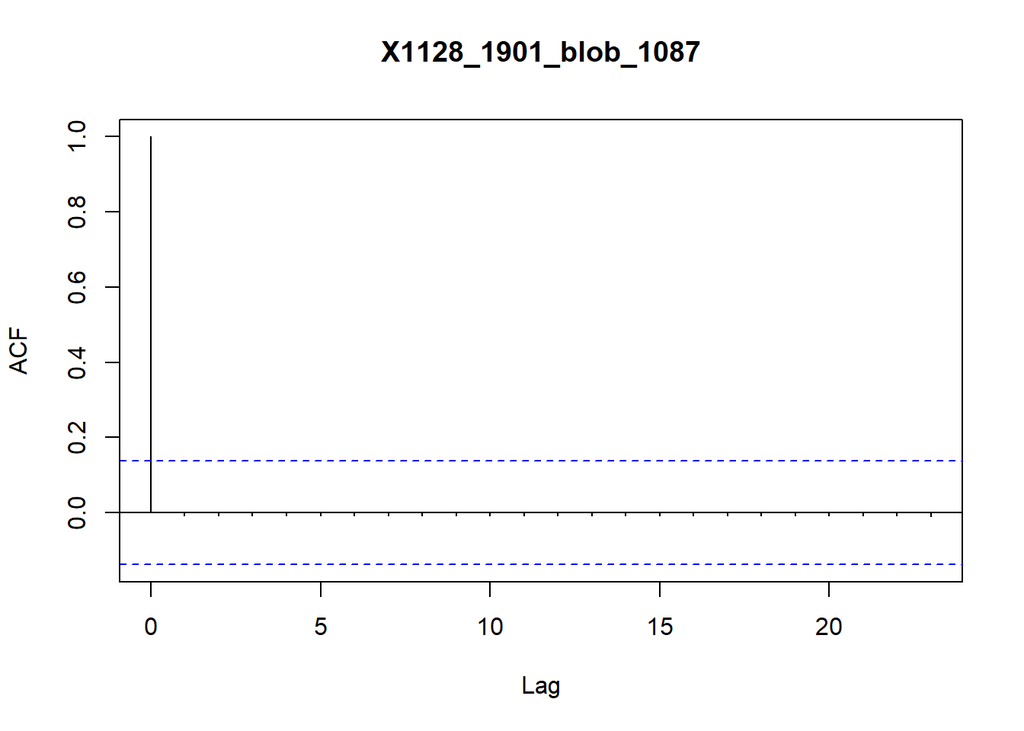

```
## [1] "X1128_1901_blob_1087 Mean: 0.0910577091811805 CV: 11.3578166916005"
```

[6 more figures not shown]

```
## [1] "X1128_1901_blob_1115 Mean: 1.78337570732869 CV: 4.14275258626103"
```

```r
for(i in 3:20){
  #i = 3
  tseries_temp <- M_t_analyte_unique_na2r.w[,i]
  acf(tseries_temp, na.action = na.pass)
  temp.mean = colMeans(tseries_temp, na.rm = TRUE)
  colname.temp = colnames(M_t_analyte_unique_na2r.w[,i] )

  vec <- pull(M_t_analyte_unique_na2r.w, colname.temp)

  cv.temp = cv(vec, na.rm = TRUE)


  print(paste(colname.temp, " Mean: ",  temp.mean, " CV: ", cv.temp, sep = ""))

}
```

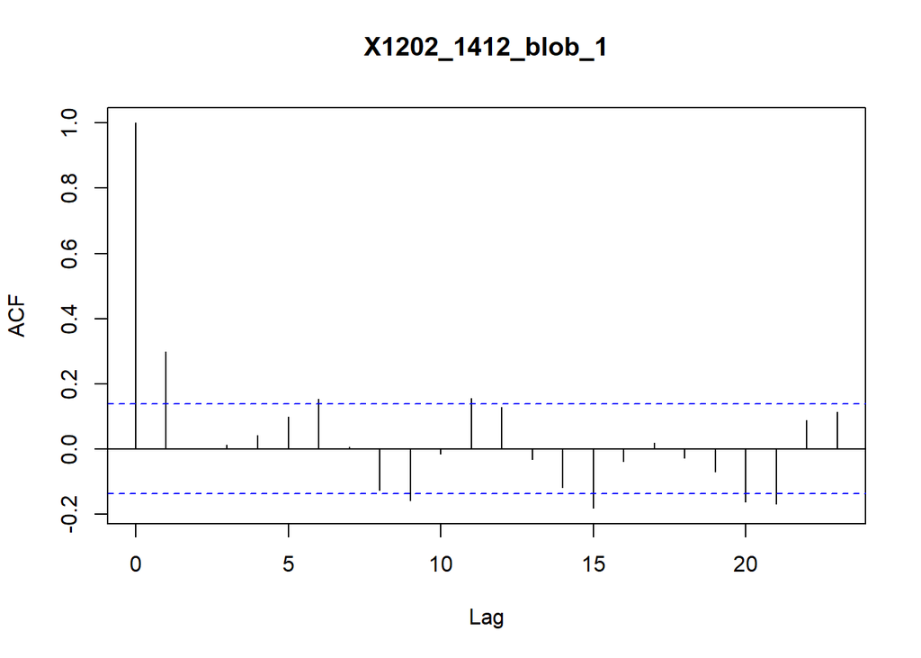

```r
# known biomass burning tracer

acf(M_t_analyte_unique_na2r.w[,"X1202_1412_blob_1"], na.action = na.pass)
```

```r
temp.mean = mean(M_t_analyte_unique_na2r.w$X1202_1412_blob_1, na.rm = TRUE)

temp.colname = "X1202_1412_blob_1"

vec <- pull(M_t_analyte_unique_na2r.w, colname.temp)

cv.temp = cv(vec, na.rm = TRUE)

print(paste(colname.temp, " Mean: ",  temp.mean, " CV: ", cv.temp, sep = ""))
```

```
## [1] "X1128_1901_blob_1115 Mean: 22263.4103777435 CV: 4.14275258626103"
```

The acf of many of my time series are periodic and have significant lags at intervals of 6. This makes sense for compounds that follow a diurnal pattern; as the samples are 4 hour time resolved, there are 6 in a day leading to a 6 point wavelength.

### 2) Plot the data [1 point].

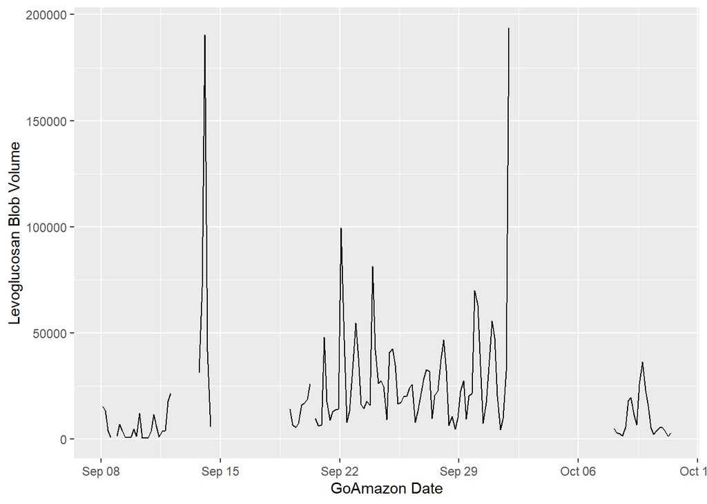

```r
M_t_analyte_unique_na2r.w %>%
  ggplot(aes(x = r_date, y = X1202_1412_blob_1))+
  geom_line()+
  ylab("Levoglucosan Blob Volume")+
  xlab("GoAmazon Date")
```

### 3) What is your main research question? Do you have any working hypothesis? [1 point].

Research Question: How does antrhopogenic pollution influence biogenic secondary organic aerosol formation?

Hypothesis: Anthropogenic activities cause increases in NOx and ozone concentrations. Increases in NOx perturb baseline oxidation chemistry causing different organic compounds to be formed, while the overall increase in oxidants leads to higher overall secondary organic aerosol yields from biogenic precursors. In the wet season, urban activities are the most significant source of NOx and anthropogenic pollutants, while in the dry season human caused biomass burning is the most significant source of NOx and increased oxidants.

### Any notes (optional)

If you need to add any additional text, please do so here (<100 words).